# Reproducible Research: Programming Assignment 1_Course Project 1

Leo Peng

2/18/2020

## 1. Loading and preprocessing the data

We set the working path and use `read.csv()` to load the data.

```r
setwd("/Users/LeoPeng/Desktop/JHU Data Science/Course Material/C5_Reproducible Research/Course Project 1")
library(ggplot2)
ori_data <- read.csv("activity.csv")
ori_data$steps <- as.numeric(ori_data$steps)
```

## 2. What is mean total number of steps taken per day?

We use the `tapply()` and `as.data.frame.table` to get a dataframe of the every day steps. Then we use `ggplot()` to plot the histogram of the total number of steps taken each day. The mean and median number of steps taken each day are also calculated.

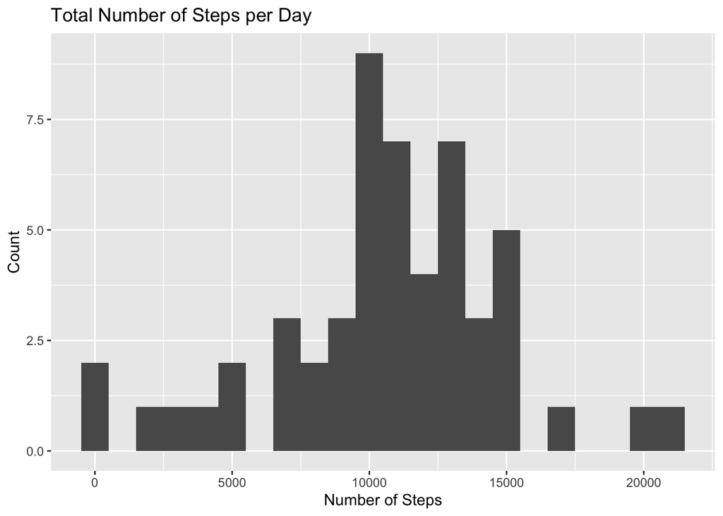

```r
sum_steps_day <- as.data.frame.table(tapply(ori_data$steps, ori_data$date, sum))
colnames(sum_steps_day) <- c("date", "steps")
ggplot(sum_steps_day, aes(x=steps)) +
    geom_histogram(binwidth=1000) +
    labs(x = "Number of Steps", y = "Count",
         title = "Total Number of Steps per Day")
```

```r
daystep_mean <- mean(sum_steps_day$steps, na.rm = TRUE)
daystep_median <- median(sum_steps_day$steps, na.rm = TRUE)
print(paste("Mean number of steps taken each day:", daystep_mean))
```

```
## [1] "Mean number of steps taken each day: 10766.1886792453"
```

```r
print(paste("Median number of steps taken each day:", daystep_median))
```

```
## [1] "Median number of steps taken each day: 10765"
```

## 3. What is the average daily activity pattern?

We use the `tapply()` and `as.data.frame.table` to get a dataframe of average stpes of each time. Then we use `ggplot()` to plot the time series plot of the average number of steps taken each time.

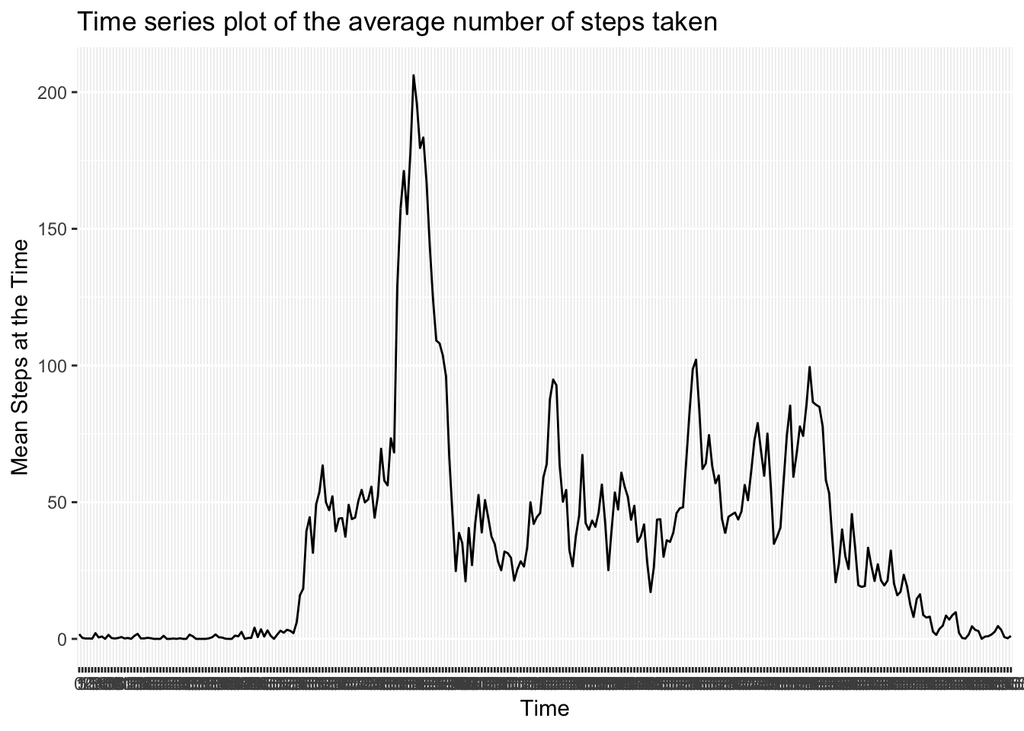

```r
sum_steps_time <- as.data.frame.table(tapply(ori_data$steps, ori_data$interval, mean, na.rm=TRUE))
colnames(sum_steps_time) <- c("time", "steps")
ggplot(sum_steps_time, aes(x=time, y=steps, group=1)) +
    geom_line(type="l") +
    labs(x = "Time", y = "Mean Steps at the Time",
         title = "Time series plot of the average number of steps taken")
```

## 4. Imputing missing values

We use the `is.na()` and `sum()` to get the number of NA data, which is 2304.

```r
sum(is.na(ori_data$steps))
```

```
## [1] 2304
```

We use the `for` loop and `if` to insert mean values of each time into the missing value. In addition, we still use `ggplot()` to plot the histogram of the total number of steps taken each day without missing values. The mean and median number of steps taken each day without missing values are also calculated.

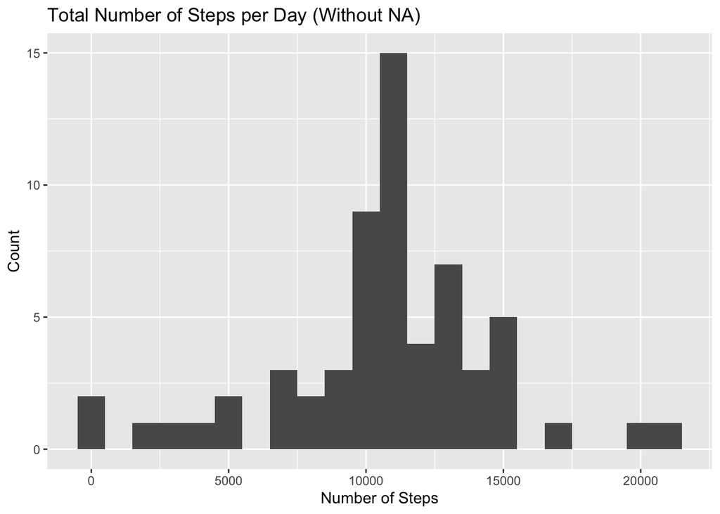

```r
wona_data <- ori_data
for (i in 1:17568) {
    if (is.na(wona_data[i,1]) == TRUE) {
        for (j in 1:288) {
            wona_data[i+j-1, 1] = sum_steps_time[j,2]
        }
    }
}
sum_steps_day_wo <- as.data.frame.table(tapply(wona_data$steps, wona_data$date, sum))
colnames(sum_steps_day_wo) <- c("date", "steps")
ggplot(sum_steps_day_wo, aes(x=steps)) +
    geom_histogram(binwidth=1000) +
    labs(x = "Number of Steps", y = "Count",
         title = "Total Number of Steps per Day (Without NA)")
```

```r
daystep_mean_wo <- mean(sum_steps_day_wo$steps)
daystep_median_wo <- median(sum_steps_day_wo$steps)
print(paste("Mean number of steps taken each day:", daystep_mean_wo))
```

```
## [1] "Mean number of steps taken each day: 10766.1886792453"
```

```r
print(paste("Median number of steps taken each day:", daystep_median_wo))
```

```
## [1] "Median number of steps taken each day: 10766.1886792453"
```

## 5. Are there differences in activity patterns between weekdays and weekends?

We use the `for` loop and `if` to insert daycategory values into the dataframe. Then, we use `aggregate` to get the mean of each day in different time. Finally, we use the `ggplot` to plot the time series plot of the average number of steps taken each time in weekdays and weekends.

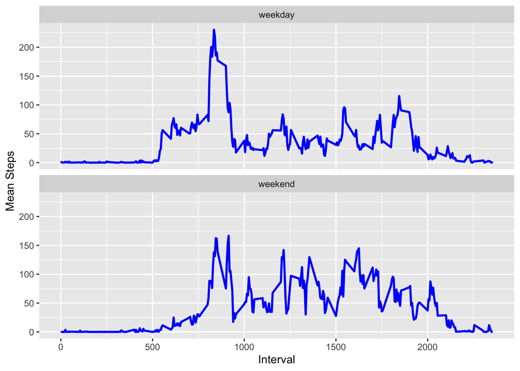

```r
wona_data_daycategory <- wona_data
wona_data_daycategory$date <- as.Date(strptime(wona_data_daycategory$date,format= "%Y-%m-%d"))
wona_data_daycategory["daycategory"] <- NA
for (i in 1:17568) {
    if (weekdays(wona_data_daycategory[i,2])== "星期六" | weekdays(wona_data_daycategory[i,2])== "星期日") {
        wona_data_daycategory[i,4] = "weekend"
    } else {
        wona_data_daycategory[i,4] = "weekday"
    }
}

final_data <- aggregate(steps ~ interval + daycategory,
                        wona_data_daycategory, mean, na.action = na.omit)

ggplot(final_data, aes(x=interval, y=steps)) +
    geom_line(color="blue", size=1) +
    facet_wrap(~ daycategory, nrow=2, ncol=1) +
    labs(x="Interval", y="Mean Steps")
```